# D212 - OFM3 TASK 2: DIMENSIONALITY REDUCTION METHODS

[Link to the Panopto Video](https://wgu.hosted.panopto.com/Panopto/Pages/Viewer.aspx?id=906cba80-768d-4a88-8177-ad4c009a3a55)

https://wgu.hosted.panopto.com/Panopto/Pages/Viewer.aspx?id=906cba80-768d-4a88-8177-ad4c009a3a55

###### --------------------------------------------------------------------------------------------------------------------------------------------------------------------------------------------------------

### Exploring the Data

#### Importing Libraries:

```python
#importing the needed libraries.
import pandas as pd
pd.set_option('display.max_rows', None)
pd.set_option('display.max_columns', None) #modified Pandas options to fully display the large dataset when needed
## !!! Trying to Display a full Dataframe may cause a problem.
import numpy as np
np.set_printoptions(precision=5, suppress=True)
import matplotlib.pyplot as plt
import seaborn as sns

import sklearn
from sklearn.preprocessing import StandardScaler
from sklearn.decomposition import PCA
```

```python
#Reading the Data file (As received) churn_clean.csv
df_raw= pd.read_csv('churn_clean.csv')
target='Churn'
df_raw.head()
```

|  | CaseOrder | Customer_id | Interaction | UID | City | State | County | Zip | Lat | Lng | Population | Area | TimeZone | Job | Children | Age | Income | Marital | Gender | Churn | Outage_sec_perweek | Email | Contacts | Yearly_equip_failure | Techie | Contract | Port_modem | Tablet | InternetService | … |
| --- | --- | --- | --- | --- | --- | --- | --- | --- | --- | --- | --- | --- | --- | --- | --- | --- | --- | --- | --- | --- | --- | --- | --- | --- | --- | --- | --- | --- | --- | --- |
| 0 | 1 | K409198 | aa90260b-4141-4a24-8e36-b04ce1f4f77b | e885b299883d4f9fb18e39c75155d990 | Point Baker | AK | Prince of Wales-Hyder | 99927 | 56.25100 | -133.37571 | 38 | Urban | America/Sitka | Environmental health practitioner | 0 | 68 | 28561.99 | Widowed | Male | No | 7.978323 | 10 | 0 | 1 | No | One year | Yes | Yes | Fiber Optic | … |
| 1 | 2 | S120509 | fb76459f-c047-4a9d-8af9-e0f7d4ac2524 | f2de8bef964785f41a2959829830fb8a | West Branch | MI | Ogemaw | 48661 | 44.32893 | -84.24080 | 10446 | Urban | America/Detroit | Programmer, multimedia | 1 | 27 | 21704.77 | Married | Female | Yes | 11.699080 | 12 | 0 | 1 | Yes | Month-to-month | No | Yes | Fiber Optic | … |
| 2 | 3 | K191035 | 344d114c-3736-4be5-98f7-c72c281e2d35 | f1784cfa9f6d92ae816197eb175d3c71 | Yamhill | OR | Yamhill | 97148 | 45.35589 | -123.24657 | 3735 | Urban | America/Los_Angeles | Chief Financial Officer | 4 | 50 | 9609.57 | Widowed | Female | No | 10.752800 | 9 | 0 | 1 | Yes | Two Year | Yes | No | DSL | … |
| 3 | 4 | D90850 | abfa2b40-2d43-4994-b15a-989b8c79e311 | dc8a365077241bb5cd5ccd305136b05e | Del Mar | CA | San Diego | 92014 | 32.96687 | -117.24798 | 13863 | Suburban | America/Los_Angeles | Solicitor | 1 | 48 | 18925.23 | Married | Male | No | 14.913540 | 15 | 2 | 0 | Yes | Two Year | No | No | DSL | … |
| 4 | 5 | K662701 | 68a861fd-0d20-4e51-a587-8a90407ee574 | aabb64a116e83fdc4befc1fbab1663f9 | Needville | TX | Fort Bend | 77461 | 29.38012 | -95.80673 | 11352 | Suburban | America/Chicago | Medical illustrator | 0 | 83 | 40074.19 | Separated | Male | Yes | 8.147417 | 16 | 2 | 1 | No | Month-to-month | Yes | No | Fiber Optic | … |

#### Data info:

```python
df_raw.info() #Data Information of the Raw DataFrame (As received)
```

```
<class 'pandas.core.frame.DataFrame'>
RangeIndex: 10000 entries, 0 to 9999
Data columns (total 50 columns):
 #   Column                Non-Null Count  Dtype
---  ------                --------------  -----
 0   CaseOrder             10000 non-null  int64
 1   Customer_id           10000 non-null  object
 2   Interaction           10000 non-null  object
 3   UID                   10000 non-null  object
 4   City                  10000 non-null  object
 5   State                 10000 non-null  object
 6   County                10000 non-null  object
 7   Zip                   10000 non-null  int64
 8   Lat                   10000 non-null  float64
 9   Lng                   10000 non-null  float64
```

[output cut: 42 more lines]

#### Summary statistics:

```python
df_raw.describe().T
```

|  | count | mean | std | min | 25% | 50% | 75% | max |
| --- | --- | --- | --- | --- | --- | --- | --- | --- |
| CaseOrder | 10000.0 | 5000.500000 | 2886.895680 | 1.000000 | 2500.750000 | 5000.500000 | 7500.250000 | 10000.000000 |
| Zip | 10000.0 | 49153.319600 | 27532.196108 | 601.000000 | 26292.500000 | 48869.500000 | 71866.500000 | 99929.000000 |
| Lat | 10000.0 | 38.757567 | 5.437389 | 17.966120 | 35.341828 | 39.395800 | 42.106908 | 70.640660 |
| Lng | 10000.0 | -90.782536 | 15.156142 | -171.688150 | -97.082813 | -87.918800 | -80.088745 | -65.667850 |
| Population | 10000.0 | 9756.562400 | 14432.698671 | 0.000000 | 738.000000 | 2910.500000 | 13168.000000 | 111850.000000 |
| Children | 10000.0 | 2.087700 | 2.147200 | 0.000000 | 0.000000 | 1.000000 | 3.000000 | 10.000000 |
| Age | 10000.0 | 53.078400 | 20.698882 | 18.000000 | 35.000000 | 53.000000 | 71.000000 | 89.000000 |
| Income | 10000.0 | 39806.926771 | 28199.916702 | 348.670000 | 19224.717500 | 33170.605000 | 53246.170000 | 258900.700000 |
| Outage_sec_perweek | 10000.0 | 10.001848 | 2.976019 | 0.099747 | 8.018214 | 10.018560 | 11.969485 | 21.207230 |
| Email | 10000.0 | 12.016000 | 3.025898 | 1.000000 | 10.000000 | 12.000000 | 14.000000 | 23.000000 |
| Contacts | 10000.0 | 0.994200 | 0.988466 | 0.000000 | 0.000000 | 1.000000 | 2.000000 | 7.000000 |
| Yearly_equip_failure | 10000.0 | 0.398000 | 0.635953 | 0.000000 | 0.000000 | 0.000000 | 1.000000 | 6.000000 |
| Tenure | 10000.0 | 34.526188 | 26.443063 | 1.000259 | 7.917694 | 35.430507 | 61.479795 | 71.999280 |
| MonthlyCharge | 10000.0 | 172.624816 | 42.943094 | 79.978860 | 139.979239 | 167.484700 | 200.734725 | 290.160419 |
| Bandwidth_GB_Year | 10000.0 | 3392.341550 | 2185.294852 | 155.506715 | 1236.470827 | 3279.536903 | 5586.141369 | 7158.981530 |
| Item1 | 10000.0 | 3.490800 | 1.037797 | 1.000000 | 3.000000 | 3.000000 | 4.000000 | 7.000000 |
| Item2 | 10000.0 | 3.505100 | 1.034641 | 1.000000 | 3.000000 | 4.000000 | 4.000000 | 7.000000 |
| Item3 | 10000.0 | 3.487000 | 1.027977 | 1.000000 | 3.000000 | 3.000000 | 4.000000 | 8.000000 |
| Item4 | 10000.0 | 3.497500 | 1.025816 | 1.000000 | 3.000000 | 3.000000 | 4.000000 | 7.000000 |
| Item5 | 10000.0 | 3.492900 | 1.024819 | 1.000000 | 3.000000 | 3.000000 | 4.000000 | 7.000000 |
| Item6 | 10000.0 | 3.497300 | 1.033586 | 1.000000 | 3.000000 | 3.000000 | 4.000000 | 8.000000 |
| Item7 | 10000.0 | 3.509500 | 1.028502 | 1.000000 | 3.000000 | 4.000000 | 4.000000 | 7.000000 |
| Item8 | 10000.0 | 3.495600 | 1.028633 | 1.000000 | 3.000000 | 3.000000 | 4.000000 | 8.000000 |

###### --------------------------------------------------------------------------------------------------------------------------------------------------------------------------------------------------------

##### Part I: Research Question

##### A. Describe the purpose of this data mining report by doing the following:

##### 1. Propose one question relevant to a real-world organizational situation that you will answer by using principal component analysis (PCA).

“Given that it costs 10 times more to acquire a new customer than to retain an existing one, customer retention has now become even more important than customer acquisition. For many providers, retaining highly profitable customers is the number one business goal. To reduce customer churn, telecommunications companies need to predict which customers are at high risk of churn.” (WGU-D212, 2021)

The company is interested in predicting the customers’ churn probability, while there is usually a big amount of irrelevant data that can be costly to collect and process without adding any value to the purpose of the analysis.

The question to be asked is about the possibility and efficiency of optimizing customer data and reducing its complexity then using this data to predict customers’ Churn, in other words, can we reduce the dimensions of data without affecting the customers’ Churn prediction?

PCA method will be used for dimensionality reduction and to answer this business question.

##### 2. Define one goal of the data analysis. Ensure that your goal is reasonable within the scope of the scenario and is represented in the available data.

The objective of the data analysis is to test the use of PCA in order to optimize the data set and reduce the number of features while keeping an amount of variance sufficient for predicting the customers’ churn probability.

###### --------------------------------------------------------------------------------------------------------------------------------------------------------------------------------------------------------

##### Part II: Method Justification

##### B. Explain the reasons for using PCA by doing the following:

##### 1. Explain how PCA analyzes the selected data set. Include expected outcomes.

#### PCA analyzes the data through the following steps:

1. all variables should be accessed on the same ratio level of measurement (Vadapalli,2020)., the original input variables are standardized ( z-scored ) (Loukas,2020), such each original variable has zero mean and unit standard deviation.
1. Constructing the eigendecomposition of the covariance matrix (in the case of standardized data the covariance is equal to the correlation matrix since the standard deviation of all features is 1) (Loukas,2020).
1. Eigenvalues are then sorted in a descending order representing decreasing variance in the data (the eigenvalues are equal to the variance) (Loukas,2020).
1. We may choose how many eigenvalues (components) to proceed with. We will lose some information while ignoring the smaller eigenvalues, but those small values supposed to not create enough impact on the final result, The selected higher eigenvalues will become the dimensions of a new updated feature set. We also form a feature vector, which is a vector matrix consisting of eigenvectors of relative chosen eigenvalues (Vadapalli,2020).
1. Using the feature vector, we find the principal components of the dataset under analysis. We multiply the transpose of the feature vector with the transpose of the scaled matrix (a scaled version of data after normalisation) to obtain a matrix containing principal components or the reduced PCA space (Vadapalli,2020).
1. The new reduced PCA space maximizes the variance of the original data (Loukas,2020).

##### 2. Summarize one assumption of PCA.

PCA assumes that the principal component with high variance must be more important than the PCs with lower variance (disregarded as noise).

Pearson correlation coefficient framework led to the origin of PCA, and there it was assumed first that the axes with high variance would only be turned into principal components (Vadapalli,2020).

This is done by projecting (dot product) the original data into the reduced PCA space using the eigenvectors of the covariance/correlation matrix aka the principal components (PCs) where reduced PCs space maximizes the variance of the original data.(Loukas,2020)

###### --------------------------------------------------------------------------------------------------------------------------------------------------------------------------------------------------------

##### Part III: Data Preparation

##### C. Perform data preparation for the chosen dataset by doing the following:

##### 1. Identify the continuous dataset variables that you will need in order to answer the PCA question proposed in part A1.

```python
numerics = ['uint8','uint16','uint32','int16', 'int32', 'int64', 'float16', 'float32', 'float64']
print('* Continuous dataset variables: \n')
print(list(df_raw.select_dtypes(include=numerics).columns))
```

```
* Continuous dataset variables:

['CaseOrder', 'Zip', 'Lat', 'Lng', 'Population', 'Children', 'Age', 'Income', 'Outage_sec_perweek', 'Email', 'Contacts', 'Yearly_equip_failure', 'Tenure', 'MonthlyCharge', 'Bandwidth_GB_Year', 'Item1', 'Item2', 'Item3', 'Item4', 'Item5', 'Item6', 'Item7', 'Item8']
```

```python
#Dropping irrelevant columns
df_ed=df_raw.copy()
drop_cols = ['CaseOrder','Customer_id','UID','Interaction','City','State','County','Zip','Lng','Lat','Population','Area','TimeZone','Job' ] #,
df_ed.drop(columns=drop_cols,inplace=True)
df_num=df_ed.copy()
df_num = df_num.select_dtypes(include=numerics)
#continuous dataset variables that you will need in order to answer the PCA question proposed in part A1
print('** Continuous dataset variables to answer the PCA question proposed in part A1: \n')
print(list(df_num.columns))
```

```
** Continuous dataset variables to answer the PCA question proposed in part A1:

['Children', 'Age', 'Income', 'Outage_sec_perweek', 'Email', 'Contacts', 'Yearly_equip_failure', 'Tenure', 'MonthlyCharge', 'Bandwidth_GB_Year', 'Item1', 'Item2', 'Item3', 'Item4', 'Item5', 'Item6', 'Item7', 'Item8']
```

```python
X=df_num.copy()
y=df_raw[target] # assigning the target to vector y
```

##### 2. Standardize the continuous dataset variables identified in part C1. Include a copy of the cleaned dataset.

```python
scaler = StandardScaler()
scaler.fit(X)
X_Standard = scaler.transform(X)
X_Standard=pd.DataFrame(X_Standard, columns=X.columns)
```

```python
# Saving a copy of the prepared data set.
D212_t2_input=X_Standard.copy()
D212_t2_input.to_csv('D212_t2_PCA_input.csv', index = True)
```

###### --------------------------------------------------------------------------------------------------------------------------------------------------------------------------------------------------------

##### Part IV: Analysis

##### D. Perform PCA by doing the following:

##### 1. Determine the matrix of all the principal components.

```python
pca = PCA()
pc=pca.fit(X_Standard)
pc=pca.transform(X_Standard)

# PC data frame
pc_names=['PC'+str(i) for i in range (1,pc.shape[1]+1)]
df_pc=pd.DataFrame(pc, columns = [*pc_names])

df_pc.head()
```

|  | PC1 | PC2 | PC3 | PC4 | PC5 | PC6 | PC7 | PC8 | PC9 | PC10 | PC11 | PC12 | PC13 | PC14 | PC15 | PC16 | PC17 | PC18 |
| --- | --- | --- | --- | --- | --- | --- | --- | --- | --- | --- | --- | --- | --- | --- | --- | --- | --- | --- |
| 0 | 1.940930 | -1.341109 | 1.841816 | 0.288136 | 1.387994 | 0.206552 | -1.427587 | 0.621163 | -0.003764 | -0.382384 | 0.292536 | 0.078412 | -0.804493 | 0.238872 | -0.161135 | -0.048228 | -0.031226 | -0.026057 |
| 1 | -0.206720 | -1.621332 | 0.528882 | -0.035193 | -0.982743 | 1.326948 | -1.048752 | 1.012969 | -0.030607 | -0.307389 | 1.469272 | 0.570945 | 0.837348 | -0.471018 | 0.220113 | -0.436375 | -0.673904 | -0.041352 |
| 2 | -0.671857 | -0.899011 | 0.228710 | -1.036460 | 0.124470 | 0.980645 | -1.613551 | -0.140147 | -0.311564 | 0.406757 | -0.414928 | -0.250632 | -0.268686 | -0.288608 | 1.018097 | -1.346966 | 0.393952 | 0.062093 |
| 3 | 0.022384 | -0.746808 | 2.186976 | 1.010421 | -1.232737 | -0.396875 | 0.141391 | -1.930475 | -0.422875 | -0.933278 | -0.361539 | -0.162086 | 0.187702 | 0.825782 | 0.430025 | 0.242809 | -0.020544 | 0.130251 |
| 4 | 1.349807 | -1.846612 | 0.712520 | 1.451670 | 1.173881 | -0.692333 | -0.035035 | -1.019783 | 1.407698 | -0.137634 | 0.332554 | 1.303887 | 0.344612 | -0.026346 | 0.108825 | 0.212092 | -0.130546 | -0.059028 |

##### 2. Identify the total number of principal components using the elbow rule or the Kaiser criterion. Include a screenshot of the scree plot.

Using the Elbow method, we can see that after the fourth principal component, the components explain a very slim amount of variance, which probably means that they are less important than the first four principal components.

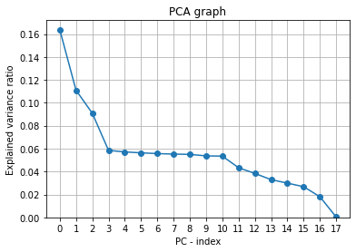

```python
plt.plot(pca.explained_variance_ratio_,'o-')
plt.grid('on')
plt.title('PCA graph')
plt.xlabel('PC - index')
plt.ylabel('Explained variance ratio')
plt.xticks(np.arange(0,len(pca.explained_variance_ratio_),step=1))
plt.ylim(0)
#plt.xlim([-1,40])
plt.show()
```

##### 3. Identify the variance of each of the principal components identified in part D2.

```python
pd.DataFrame({'pc_name' : pc_names,'variance':pca.explained_variance_ratio_}).set_index('pc_name')
```

| pc_name | variance |
| --- | --- |
| PC1 | 0.163809 |
| PC2 | 0.110938 |
| PC3 | 0.090912 |
| PC4 | 0.058464 |
| PC5 | 0.057102 |
| PC6 | 0.056309 |
| PC7 | 0.055664 |
| PC8 | 0.055204 |
| PC9 | 0.054973 |
| PC10 | 0.053643 |
| PC11 | 0.053451 |
| PC12 | 0.043299 |
| PC13 | 0.038347 |
| PC14 | 0.032910 |
| PC15 | 0.029875 |
| PC16 | 0.026764 |
| PC17 | 0.018032 |
| PC18 | 0.000303 |

##### 4. Identify the total variance captured by the principal components identified in part D2.

```
 ** Total Variance Captured (Before Reduction)=  1.0
```

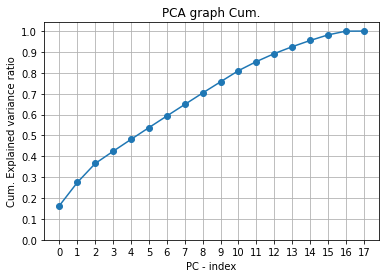

```python
print('\n ** Total Variance Captured (Before Reduction)= ',round(pca.explained_variance_ratio_.sum(),3),'\n')
plt.plot(pca.explained_variance_ratio_.cumsum(),'o-')
plt.grid('on')
plt.title('PCA graph Cum.')
plt.xlabel('PC - index')
plt.ylabel('Cum. Explained variance ratio')
plt.xticks(np.arange(0,len(pca.explained_variance_ratio_),step=1))
plt.yticks(np.arange(0,1.1,0.1))
#plt.ylim([-0.01,0.17])
#plt.xlim([-1,40])
plt.show()
```

|  | PC1 | PC2 | PC3 | PC4 | PC5 | PC6 | PC7 | PC8 | PC9 | PC10 | PC11 | PC12 | PC13 | PC14 | PC15 | PC16 | PC17 | PC18 |
| --- | --- | --- | --- | --- | --- | --- | --- | --- | --- | --- | --- | --- | --- | --- | --- | --- | --- | --- |
| Bandwidth_GB_Year | 0.016854 | 0.703834 | 0.062300 | 0.009094 | 0.019781 | 0.011580 | 0.004337 | 0.003668 | 0.000829 | 0.001622 | 0.008054 | 0.010791 | 0.003378 | 0.005656 | 0.006121 | 0.002174 | 0.001822 | 0.706780 |
| Tenure | 0.016329 | 0.702329 | 0.063268 | 0.000048 | 0.021252 | 0.040990 | 0.005255 | 0.033568 | 0.008052 | 0.035683 | 0.015262 | 0.005938 | 0.003505 | 0.006550 | 0.007772 | 0.004625 | 0.007520 | 0.705251 |
| Item5 | 0.175689 | 0.056364 | 0.587123 | 0.043191 | 0.018466 | 0.015657 | 0.002734 | 0.001940 | 0.013202 | 0.011902 | 0.010075 | 0.136400 | 0.058673 | 0.206538 | 0.694057 | 0.264938 | 0.041833 | 0.000812 |
| MonthlyCharge | 0.000925 | 0.039835 | 0.009424 | 0.352348 | 0.308413 | 0.341549 | 0.017170 | 0.662362 | 0.186541 | 0.336448 | 0.268693 | 0.004431 | 0.014211 | 0.016272 | 0.000086 | 0.021558 | 0.011989 | 0.045776 |
| Item4 | 0.145791 | 0.039469 | 0.568470 | 0.016916 | 0.003825 | 0.011564 | 0.026188 | 0.003151 | 0.021383 | 0.016475 | 0.019985 | 0.172805 | 0.480770 | 0.442775 | 0.431868 | 0.088653 | 0.018714 | 0.000107 |
| Item2 | 0.433849 | 0.038795 | 0.282423 | 0.025012 | 0.008140 | 0.014525 | 0.001277 | 0.009136 | 0.008689 | 0.007551 | 0.014014 | 0.111856 | 0.169995 | 0.066547 | 0.073953 | 0.590723 | 0.573522 | 0.001142 |
| Item3 | 0.400493 | 0.035557 | 0.280520 | 0.002064 | 0.008762 | 0.029523 | 0.034627 | 0.006344 | 0.010011 | 0.015056 | 0.010925 | 0.175568 | 0.249741 | 0.147378 | 0.395933 | 0.673827 | 0.176890 | 0.000076 |
| Item1 | 0.458674 | 0.031390 | 0.280980 | 0.013906 | 0.003668 | 0.015552 | 0.022534 | 0.007753 | 0.005371 | 0.018349 | 0.020134 | 0.069067 | 0.116927 | 0.046521 | 0.025062 | 0.240496 | 0.792978 | 0.002979 |
| Email | 0.008764 | 0.020511 | 0.003873 | 0.095033 | 0.431931 | 0.471086 | 0.041843 | 0.198158 | 0.670080 | 0.182895 | 0.233141 | 0.056960 | 0.015958 | 0.017102 | 0.006496 | 0.017449 | 0.000899 | 0.000220 |
| Yearly_equip_failure | 0.007693 | 0.017579 | 0.008310 | 0.139135 | 0.383547 | 0.526789 | 0.322116 | 0.312514 | 0.427095 | 0.024405 | 0.412170 | 0.021693 | 0.006281 | 0.015708 | 0.001320 | 0.007534 | 0.021434 | 0.000143 |
| Children | 0.004065 | 0.015831 | 0.028550 | 0.556582 | 0.284705 | 0.150677 | 0.068097 | 0.089403 | 0.273747 | 0.542787 | 0.448763 | 0.018327 | 0.012509 | 0.013825 | 0.014474 | 0.020975 | 0.000930 | 0.021613 |
| Item8 | 0.308742 | 0.013596 | 0.131870 | 0.021115 | 0.000924 | 0.063013 | 0.008638 | 0.026683 | 0.029096 | 0.065765 | 0.071934 | 0.923182 | 0.016330 | 0.114088 | 0.045620 | 0.045232 | 0.043288 | 0.001998 |
| Item6 | 0.405082 | 0.006649 | 0.183618 | 0.002449 | 0.000952 | 0.004394 | 0.015645 | 0.009620 | 0.018209 | 0.006180 | 0.014817 | 0.058921 | 0.060841 | 0.759636 | 0.400539 | 0.229058 | 0.063850 | 0.000595 |
| Income | 0.001029 | 0.005988 | 0.026087 | 0.214541 | 0.281181 | 0.163509 | 0.788035 | 0.229458 | 0.260000 | 0.315065 | 0.002249 | 0.018256 | 0.079568 | 0.007302 | 0.002581 | 0.005387 | 0.013494 | 0.000907 |
| Outage_sec_perweek | 0.017510 | 0.003956 | 0.014502 | 0.217254 | 0.486102 | 0.564543 | 0.013564 | 0.259471 | 0.035974 | 0.470477 | 0.312407 | 0.091894 | 0.017116 | 0.008866 | 0.013538 | 0.018217 | 0.013499 | 0.000360 |
| Contacts | 0.008756 | 0.003340 | 0.011962 | 0.458269 | 0.024598 | 0.055432 | 0.487602 | 0.534958 | 0.115637 | 0.478287 | 0.125450 | 0.043870 | 0.035057 | 0.003437 | 0.026489 | 0.020213 | 0.000827 | 0.000950 |
| Item7 | 0.358235 | 0.001992 | 0.181214 | 0.024330 | 0.022973 | 0.019180 | 0.072422 | 0.015635 | 0.011216 | 0.006543 | 0.017338 | 0.174456 | 0.804965 | 0.376424 | 0.071212 | 0.067129 | 0.041257 | 0.000491 |
| Age | 0.006471 | 0.000351 | 0.029584 | 0.479937 | 0.415095 | 0.069419 | 0.150357 | 0.088364 | 0.417584 | 0.045274 | 0.617756 | 0.048272 | 0.003065 | 0.002873 | 0.009380 | 0.005677 | 0.013661 | 0.022418 |

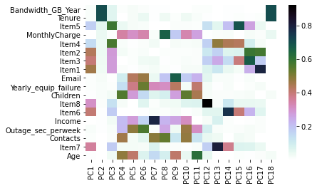

```python
loadings = pd.DataFrame(pca.components_.T,columns = [*pc_names],index=X_Standard.columns)
display(loadings.abs().sort_values(by='PC2',ascending =False))
sns.heatmap(loadings.abs().sort_values(by='PC2',ascending =False),annot=False,cmap="cubehelix_r")
```

## Rerunning PCA using the selected number of principal components:

```python
pca = PCA(n_components=4)
pc=pca.fit(X_Standard)
pc=pca.transform(X_Standard)

# PC data frame
pc_names=['PC'+str(i) for i in range (1,pc.shape[1]+1)]
df_pc=pd.DataFrame(pc, columns = [*pc_names])

df_pc.head()
```

|  | PC1 | PC2 | PC3 | PC4 |
| --- | --- | --- | --- | --- |
| 0 | 1.941017 | -1.341157 | 1.844348 | 0.353248 |
| 1 | -0.206632 | -1.620915 | 0.530058 | -0.098507 |
| 2 | -0.671832 | -0.900313 | 0.225231 | -0.934717 |
| 3 | 0.022219 | -0.747111 | 2.184796 | 0.931046 |
| 4 | 1.350659 | -1.845932 | 0.733366 | 1.241429 |

```python
pd.DataFrame({'pc_name' : pc_names,'variance':pca.explained_variance_ratio_}).set_index('pc_name')
```

| pc_name | variance |
| --- | --- |
| PC1 | 0.163809 |
| PC2 | 0.110938 |
| PC3 | 0.090900 |
| PC4 | 0.058150 |

#### Total Variance Captured after Reduction :

```
 ** Total Variance Captured (After Reduction) =  0.424
```

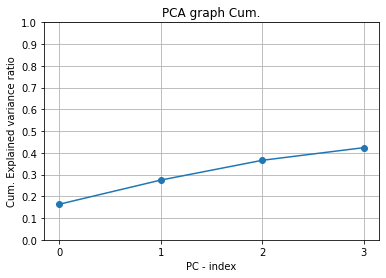

```python
print('\n ** Total Variance Captured (After Reduction) = ',round(pca.explained_variance_ratio_.sum(),3),'\n')
plt.plot(pca.explained_variance_ratio_.cumsum(),'o-')
plt.grid('on')
plt.title('PCA graph Cum.')
plt.xlabel('PC - index')
plt.ylabel('Cum. Explained variance ratio')
plt.xticks(np.arange(0,len(pca.explained_variance_ratio_),step=1))
plt.yticks(np.arange(0,1.1,0.1))
#plt.ylim([-0.01,0.17])
#plt.xlim([-1,40])
plt.show()
```

#### Testing the results in order to answer the PCA question proposed in part A1:

```python
y=pd.get_dummies(y,drop_first=True,columns=target)
```

```python
'''
Custom function , takes 2 arguments as 2 data frames:
1- input features data frame
2- actual target that need to be tested relative to PCA

The output is a series of cross plots , each cross plot is an xplot between two PCs of the input data frame, where points
are colored by :
- actual target that need to be tested relative to PCA
'''

def pc_visual(pc_df,target_df):
#     print(" -  Colored by " + target )
    displayed = [];pair1={};pair2={}
    for n, col1 in enumerate(pc_df.columns):   #enumerating each column of the data, starting from index
        for m, col2 in enumerate(pc_df.columns):
            pair1 = {col1:col2}
            pair2={col2:col1}
            if ((col1 == col2) or (pair1 in displayed) or (pair2 in displayed)):
                continue
            displayed.append(pair1)
            displayed.append(pair2)
            plt.figure(figsize=(6,3))
            ax1=plt.subplot2grid(shape=(1,1),loc=(0,0))
            ax1=plt.scatter(pc_df.loc[:,col1],pc_df.loc[:,col2],c=target_df.iloc[:,0],s=5,cmap='plasma',alpha=0.1) #plotting scatterd plot against the index of the D.F.
#             ax1.grid(True)
            plt.colorbar(ax1)
            plt.title('[Colored by ' + 'Actual '+target+']',fontsize = 9)
            #plt.title(col1+" Vs "+col2+" -  [Colored by " + 'Clusters]' ,fontsize = 9)
            plt.xlabel(col1,fontsize = 8);
            plt.ylabel(col2,fontsize = 8)
            plt.xticks(fontsize = 6)
            plt.yticks(fontsize = 6)

            plt.tight_layout()
            plt.show()
```

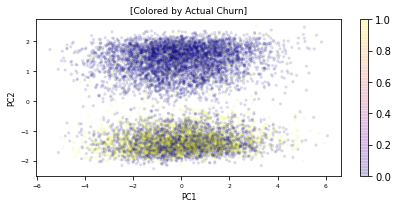

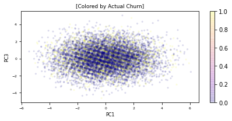

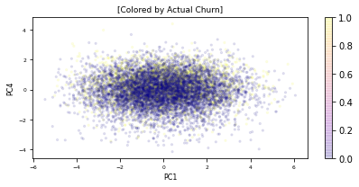

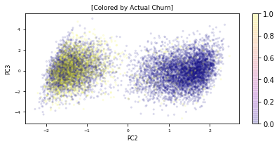

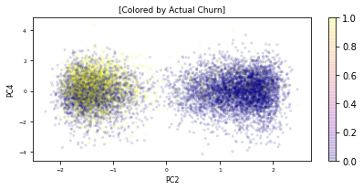

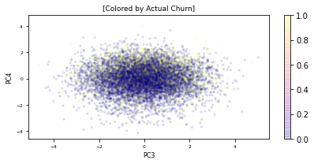

```python
pc_visual(df_pc,y)
```

|  | PC1 | PC2 | PC3 | PC4 |
| --- | --- | --- | --- | --- |
| Bandwidth_GB_Year | 0.016851 | 0.703837 | 0.062201 | 0.012966 |
| Tenure | 0.016329 | 0.702324 | 0.063241 | 0.000269 |
| Item5 | 0.175557 | 0.056524 | 0.590089 | 0.023223 |
| MonthlyCharge | 0.000999 | 0.039998 | 0.007253 | 0.299498 |
| Item4 | 0.145905 | 0.039304 | 0.566554 | 0.028025 |
| Item2 | 0.433828 | 0.038701 | 0.280844 | 0.037806 |
| Item3 | 0.400447 | 0.036117 | 0.281010 | 0.020842 |
| Item1 | 0.458681 | 0.030887 | 0.280938 | 0.027507 |
| Email | 0.008970 | 0.020371 | 0.001432 | 0.095667 |
| Yearly_equip_failure | 0.007659 | 0.017511 | 0.008883 | 0.085538 |
| Children | 0.004127 | 0.015765 | 0.029755 | 0.606595 |
| Item8 | 0.309048 | 0.013249 | 0.125285 | 0.023534 |
| Item6 | 0.404995 | 0.006889 | 0.185474 | 0.016512 |
| Income | 0.000901 | 0.005912 | 0.022795 | 0.101343 |
| Outage_sec_perweek | 0.017618 | 0.003953 | 0.016914 | 0.257848 |
| Contacts | 0.008716 | 0.003351 | 0.011027 | 0.501911 |
| Item7 | 0.358147 | 0.002103 | 0.182947 | 0.010121 |
| Age | 0.006611 | 0.000446 | 0.025792 | 0.438364 |

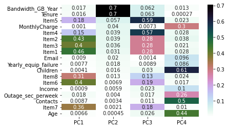

```python
loadings = pd.DataFrame(pca.components_.T,columns = [*pc_names],index=X_Standard.columns)
display(loadings.abs().sort_values(by='PC2',ascending =False))
sns.heatmap(loadings.abs().sort_values(by='PC2',ascending =False),annot=True,cmap="cubehelix_r")
```

##### 5. Summarize the results of your data analysis.

PCA is an unsupervised dimensionality reduction technique depending on the variance of input features and maximizing the separation or segregation of observations (variance), regardless of the meaning or the significance of this variance.

But for the purpose of this analysis, some measures had been taken to utilize the PCA technique in order to optimize the data set and reduce the number of features while keeping an amount of variance sufficient for predicting the customers’ churn probability.

The PCA helped to reduce the number of features from 18 to 4 (selected according to elbow method), even though a high amount of data variance has been sacrificed (from 1 to 0.4) but overall, for the purpose of the analysis, the reduced PCs could give a good dimensionality or space for clustering or separating the customers who have higher Chusrn probability and can be used next in predicting this probability.

The testing results can be viewed visually in the previous plots.

###### --------------------------------------------------------------------------------------------------------------------------------------------------------------------------------------------------------

##### Part V: Attachments

##### E. Record the web sources used to acquire data or segments of third-party code to support the analysis. Ensure the web sources are reliable.

##### F. Acknowledge sources, using in-text citations and references, for content that is quoted, paraphrased, or summarized.

##### G. Demonstrate professional communication in the content and presentation of your submission

[Link to the Panopto Video](https://wgu.hosted.panopto.com/Panopto/Pages/Viewer.aspx?id=906cba80-768d-4a88-8177-ad4c009a3a55)

https://wgu.hosted.panopto.com/Panopto/Pages/Viewer.aspx?id=906cba80-768d-4a88-8177-ad4c009a3a55

###### --------------------------------------------------------------------------------------------------------------------------------------------------------------------------------------------------------

### References:

- WGU. D212 Data Mining II (2021, June 16), Data Files and Associated Dictionary Files. https://access.wgu.edu/ASP3/aap/content/gkridh34kd85jf94dcj2.zip
- Serafeim Loukas. (2020 ). PCA clearly explained—When, Why, How to use it and feature importance: A guide in Python. https://towardsdatascience.com/pca-clearly-explained-how-when-why-to-use-it-and-feature-importance-a-guide-in-python-7c274582c37e
- Pavan Vadapalli. (2020) . PCA in Machine Learning: Assumptions, Steps to Apply & Applications. https://www.upgrad.com/blog/pca-in-machine-learning/#:~:text=The%20assumptions%20in%20PCA%20are%3A%20%E2%80%A2%20There%20must,PCs%20with%20lower%20variance%20are%20disregarded%20as%20noise.
- (datacamp) Data Mining II – D212 course materials and Labs https://learn.datacamp.com/custom-tracks/custom-data-mining-ii
- https://www.udemy.com/course/python-for-data-science-machine-learning/
- https://www.udemy.com/course/data-science-bootcamp-with-python/
- Scikit-learn Crash Course - Machine Learning Library for Python https://www.youtube.com/watch?v=0B5eIE_1vpU
- General Questions/Answers from https://stackoverflow.com/
- Documentation of Python packages: pandas, matplotlib,numpy,sklearn and scipy
- Feature Scaling in Machine Learning(Normalization & Standardization) | Feature Scaling Sklearn https://www.youtube.com/watch?v=wNa_VI__j84